# Modeling (Logistic Regression)

## Results

Now let’s examine how performance various across these different training-testing splits and different features sets.

### Results (Collect Summary Statistics)

First, I averaged together the results of the 10 models for each of the subsets of the analyses (e.g. in the first first row, we can see that the overall accuracy across 10 different models, trained only on the statement length features, with a 1% training set, 99% test set split is 50.2%). It will be easier to assess these results visually.

```r
# get average for each round
results_summ <-
  results %>%
    # dplyr::mutate(split = as.factor(split)) %>%
    dplyr::group_by(feature_set, split) %>%
    dplyr::summarise(avg_accuracy = mean(accuracy),
                     min_accuracy = min(accuracy),
                     max_accuracy = max(accuracy),
                     avg_sensitivity = mean(sensitivity),
                     min_sensitivity = min(sensitivity),
                     max_sensitivity = max(sensitivity),
                     avg_specificity = mean(specificity),
                     min_specificity = min(specificity),
                     max_specificity = max(specificity),
                     avg_precision = mean(precision),
                     min_precision = min(precision),
                     max_precision = max(precision)) %>%
  ungroup() %>%
  mutate(feature_set = factor(feature_set,
                              levels = c("top 10 words",
                                         "top 25 words",
                                         "top 50 words",
                                         "top 100 words",
                                         "length",
                                         "readability",
                                         "parts of speech",
                                         "sentiment")))
# look over results
results_summ
```

| feature_set | split | avg_accuracy | min_accuracy | max_accuracy | avg_sensitivity | min_sensitivity | max_sensitivity | avg_specificity | min_specificity | max_specificity | avg_precision | min_precision | max_precision |
| --- | --- | --- | --- | --- | --- | --- | --- | --- | --- | --- | --- | --- | --- |
| length | 0.01 | 0.5020598 | 0.4753635 | 0.5207997 | 0.4308966 | 0.1922456 | 0.5193861 | 0.5732229 | 0.4470921 | 0.8101777 | 0.5036744 | 0.4759843 | 0.5272631 |
| length | 0.02 | 0.4967156 | 0.4793962 | 0.5187678 | 0.5017952 | 0.2798858 | 0.7466340 | 0.4916361 | 0.2166463 | 0.7576499 | 0.4981770 | 0.4756392 | 0.5359375 |
| length | 0.05 | 0.5063763 | 0.4764310 | 0.5216751 | 0.5137626 | 0.3324916 | 0.7196970 | 0.4989899 | 0.2630471 | 0.6203704 | 0.5059569 | 0.4669031 | 0.5230425 |
| length | 0.10 | 0.5088849 | 0.4797868 | 0.5193247 | 0.4693914 | 0.3314083 | 0.6179476 | 0.5483785 | 0.3896046 | 0.6992448 | 0.5112329 | 0.4803795 | 0.5242446 |
| length | 0.20 | 0.5005497 | 0.4735132 | 0.5179910 | 0.4582709 | 0.2888556 | 0.6601699 | 0.5428286 | 0.2898551 | 0.7276362 | 0.5022497 | 0.4684148 | 0.5231959 |
| length | 0.30 | 0.5125642 | 0.4922901 | 0.5208452 | 0.4631639 | 0.3992005 | 0.5562536 | 0.5619646 | 0.4414620 | 0.6333524 | 0.5145490 | 0.4930016 | 0.5268976 |
| length | 0.40 | 0.5119254 | 0.4960027 | 0.5239840 | 0.4335110 | 0.3724184 | 0.6575616 | 0.5903398 | 0.3344437 | 0.6668887 | 0.5157122 | 0.4969789 | 0.5324324 |
| length | 0.50 | 0.5124700 | 0.5031974 | 0.5227818 | 0.3981615 | 0.3405276 | 0.4404476 | 0.6267786 | 0.5755396 | 0.6874500 | 0.5164585 | 0.5037383 | 0.5308776 |
| length | 0.60 | 0.5185000 | 0.5095000 | 0.5255000 | 0.4485000 | 0.3540000 | 0.5200000 | 0.5885000 | 0.5110000 | 0.6960000 | 0.5220375 | 0.5109573 | 0.5379939 |
| length | 0.70 | 0.5165333 | 0.5013333 | 0.5386667 | 0.4185333 | 0.3266667 | 0.4906667 | 0.6145333 | 0.5413333 | 0.7506667 | 0.5221924 | 0.5014837 | 0.5671296 |

[output cut: 86 more lines]

### Results (Overall Accuracy)

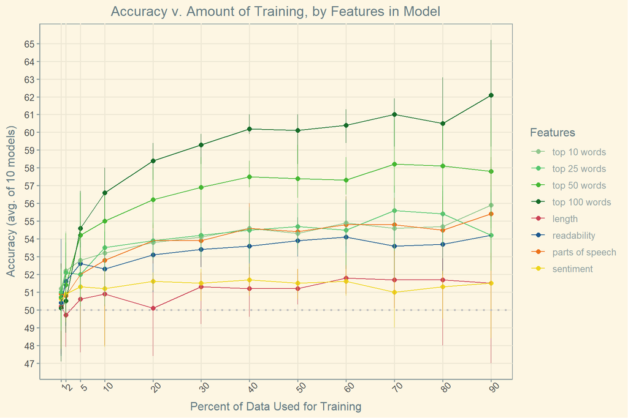

```r
# set colors
color_map <- c("top 10 words" = "#91C68D",
               "top 25 words" = "#55C66E",
               "top 50 words" = "#45B731",
               "top 100 words" = "#166B28",
               "length" = "#CB4154",
               "readability" = "#1D588E",
               "parts of speech" = "#ED721A",
               "sentiment" = "#EDD41A")

# recreated split_probs variale here (created in non-evaluted chunk, but used for graph)
split_probs <- c(0.01, 0.02, 0.05, seq(from = 0.10, to = 0.90, by = 0.10))

# print plot
ggplot(data = results_summ,
       aes(x = round(split * 100, 1),
           y = round(avg_accuracy * 100, 1),
           color = feature_set)) +
  geom_point(size = 2) +
  geom_line(size = 0.5) +
  geom_errorbar(aes(ymin = round(min_accuracy * 100, 1),
                  ymax = round(max_accuracy * 100, 1)),
                alpha = 0.5,
                width = 0) +
  geom_hline(yintercept = 50,
             color = "grey",
             linetype = "dotted",
             size = 1) +
  scale_x_continuous(breaks = (split_probs * 100)) +
  scale_y_continuous(breaks = seq(from = 47, to = 65, by = 1)) +
  scale_color_manual(values = color_map) +
  labs(x = "Percent of Data Used for Training",
       y = "Accuracy (avg. of 10 models)",
       title = "Accuracy v. Amount of Training, by Features in Model",
       color = "Features") +
  theme_solarized() +
  theme(plot.title = element_text(hjust = 0.5),
        axis.text.x = element_text(angle = 45),
        panel.grid.minor = element_blank(),
        legend.key = element_rect(color = "transparent", fill = "transparent"),
        axis.title.y = element_text(margin = margin(t = 0, r = 8, b = 0, l = 0)))
```